# Tugas Pertemuan 2 - Metode Pemulusan Deret Waktu

Tita Ayu Pramesti

29 August 2026

# Deskripsi Data

Data yang digunakan adalah anomali suhu global bulanan (global temperature anomaly) dalam satuan derajat Celsius, periode April 1993 - Juli 2001, sebanyak 100 observasi (bagian data individu dari kelompok).

# Library/Packages

Package yang digunakan pada analisis ini adalah `forecast`, `graphics`, `TTR`, dan `rio`.

```r
library("forecast")
library("graphics")
library("TTR")
library("rio")
```

# Impor Data

```r
data1 <- import("data mpdw untuk praktikum.xlsx")
head(data1)
```

```
##   timestamp global_temperature_anomaly_C
## 1   1993-04                         0.28
## 2   1993-05                         0.28
## 3   1993-06                         0.22
## 4   1993-07                         0.25
## 5   1993-08                         0.11
## 6   1993-09                         0.11
```

# Eksplorasi Data

```r
str(data1)
```

```
## 'data.frame':    100 obs. of  2 variables:
##  $ timestamp                   : chr  "1993-04" "1993-05" "1993-06" "1993-07" ...
##  $ global_temperature_anomaly_C: num  0.28 0.28 0.22 0.25 0.11 0.11 0.23 0.03 0.18 0.26 ...
```

```r
dim(data1)
```

```
## [1] 100   2
```

```r
data1.ts <- ts(data1$global_temperature_anomaly_C)
summary(data1.ts)
```

```
##    Min. 1st Qu.  Median    Mean 3rd Qu.    Max.
##  0.0200  0.2975  0.4000  0.4048  0.5050  0.8800
```

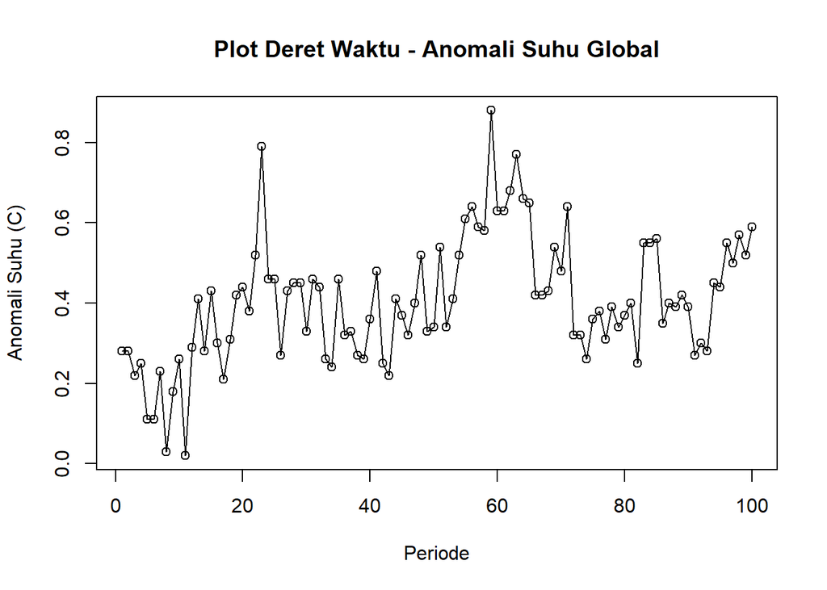

```r
ts.plot(data1.ts, xlab = "Periode", ylab = "Anomali Suhu (C)",
        main = "Plot Deret Waktu - Anomali Suhu Global")
points(data1.ts)
```

Berdasarkan plot di atas, data memperlihatkan **pola tren naik** dengan fluktuasi/noise di sekitarnya, dan secara visual tidak menunjukkan pola musiman (seasonal) yang jelas – hal ini wajar karena data anomali suhu pada dasarnya sudah merupakan deviasi terhadap rata-rata klimatologis bulanan, sehingga efek musiman relatif sudah hilang. Untuk memvalidasi dugaan tersebut, pada analisis ini tetap diterapkan **enam metode** pemulusan yang telah dipelajari, yaitu **SMA, DMA, SES, DES, Winter Aditif, dan Winter Multiplikatif**, kemudian dibandingkan kinerjanya menggunakan SSE, MSE, dan MAPE.

# Pembagian Data

Data dibagi menjadi 80% data latih dan 20% data uji.

```r
n <- nrow(data1)
n_train <- floor(0.8 * n)

training <- data1[1:n_train, ]
testing  <- data1[(n_train + 1):n, ]

train.ts <- ts(training$global_temperature_anomaly_C)
test.ts  <- ts(testing$global_temperature_anomaly_C)

n_train
```

```
## [1] 80
```

```r
n - n_train
```

```
## [1] 20
```

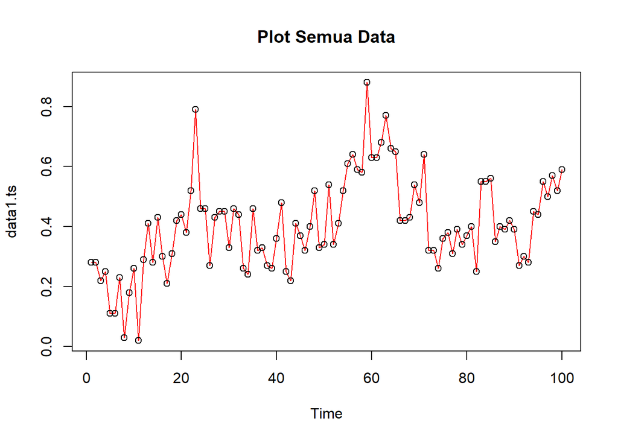

```r
plot(data1.ts, col = "red", main = "Plot Semua Data")
points(data1.ts)
```

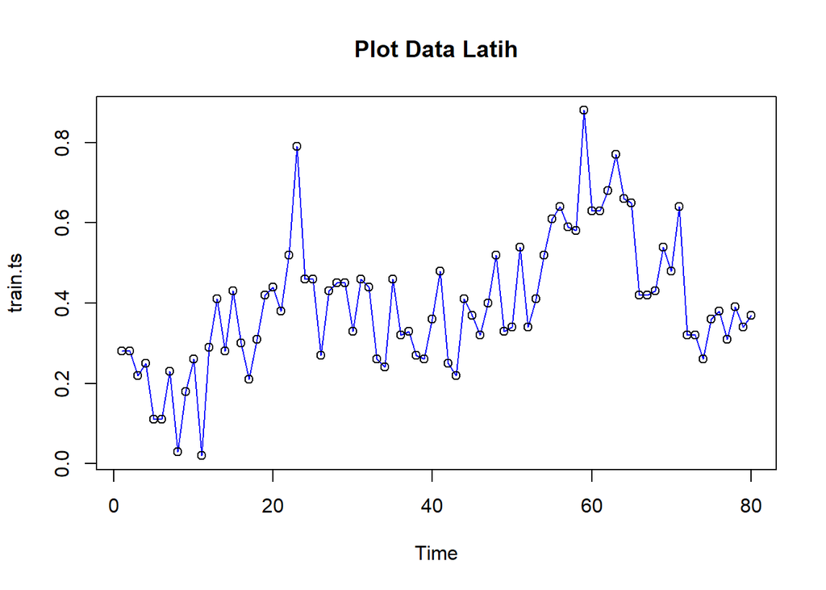

```r
plot(train.ts, col = "blue", main = "Plot Data Latih")
points(train.ts)
```

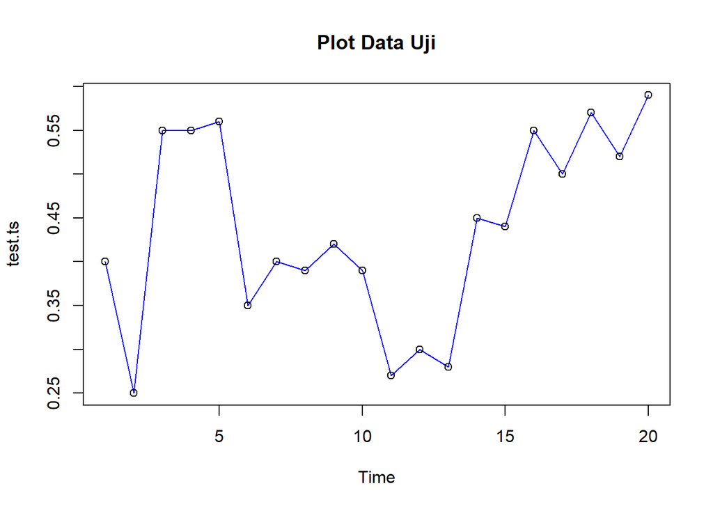

```r
plot(test.ts, col = "blue", main = "Plot Data Uji")
points(test.ts)
```

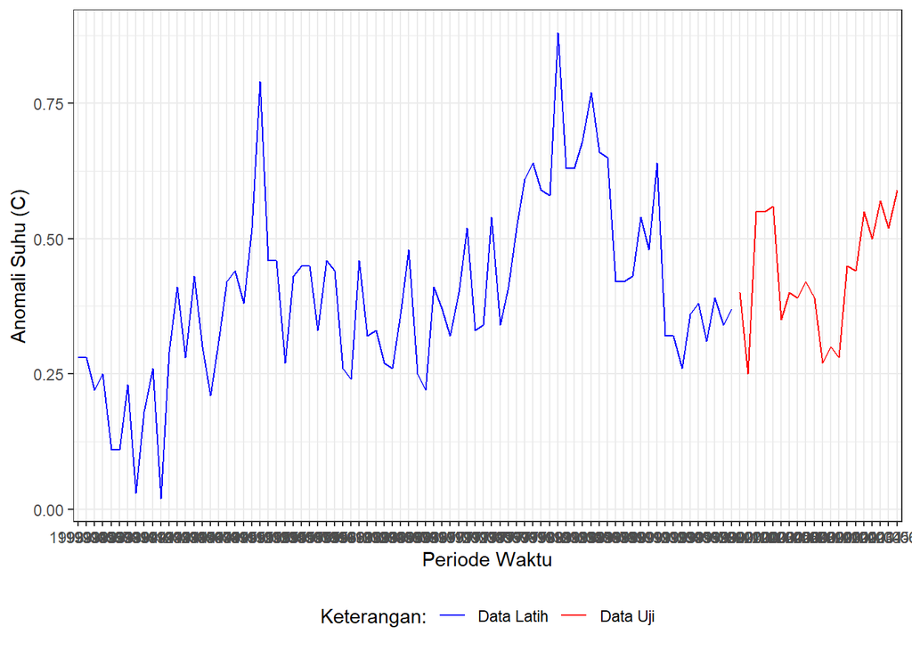

```r
library(ggplot2)
ggplot() +
  geom_line(data = training, aes(x = timestamp, y = global_temperature_anomaly_C, col = "Data Latih", group = 1)) +
  geom_line(data = testing, aes(x = timestamp, y = global_temperature_anomaly_C, col = "Data Uji", group = 1)) +
  labs(x = "Periode Waktu", y = "Anomali Suhu (C)", color = "Keterangan:") +
  scale_colour_manual(breaks = c("Data Latih", "Data Uji"),
                      values = c("blue", "red")) +
  theme_bw() +
  theme(legend.position = "bottom",
        plot.caption = element_text(hjust = 0.5, size = 12))
```

# Metode 1: Single Moving Average (SMA)

```r
data.sma <- SMA(train.ts, n = 4)
data.sma
```

```
## Time Series:
## Start = 1
## End = 80
## Frequency = 1
##  [1]     NA     NA     NA 0.2575 0.2150 0.1725 0.1750 0.1200 0.1375 0.1750
## [11] 0.1225 0.1875 0.2450 0.2500 0.3525 0.3550 0.3050 0.3125 0.3100 0.3450
## [21] 0.3875 0.4400 0.5325 0.5375 0.5575 0.4950 0.4050 0.4025 0.4000 0.4150
## [31] 0.4225 0.4200 0.3725 0.3500 0.3500 0.3200 0.3375 0.3450 0.2950 0.3050
## [41] 0.3425 0.3375 0.3275 0.3400 0.3125 0.3300 0.3750 0.4025 0.3925 0.3975
## [51] 0.4325 0.3875 0.4075 0.4525 0.4700 0.5450 0.5900 0.6050 0.6725 0.6700
## [61] 0.6800 0.7050 0.6775 0.6850 0.6900 0.6250 0.5375 0.4800 0.4525 0.4675
## [71] 0.5225 0.4950 0.4400 0.3850 0.3150 0.3300 0.3275 0.3600 0.3550 0.3525
```

```r
data.ramal.sma <- c(NA, data.sma)
forecast.sma <- rep(data.ramal.sma[length(data.ramal.sma)], length(test.ts) - 1)

data.gab.sma <- cbind(
  aktual = c(data1.ts),
  pemulusan = c(data.sma, rep(NA, length(test.ts))),
  ramalan = c(data.ramal.sma, rep(data.ramal.sma[length(data.ramal.sma)], length(test.ts) - 1))
)
data.gab.sma
```

```
##        aktual pemulusan ramalan
##   [1,]   0.28        NA      NA
##   [2,]   0.28        NA      NA
##   [3,]   0.22        NA      NA
##   [4,]   0.25    0.2575      NA
##   [5,]   0.11    0.2150  0.2575
##   [6,]   0.11    0.1725  0.2150
##   [7,]   0.23    0.1750  0.1725
##   [8,]   0.03    0.1200  0.1750
##   [9,]   0.18    0.1375  0.1200
##  [10,]   0.26    0.1750  0.1375
##  [11,]   0.02    0.1225  0.1750
##  [12,]   0.29    0.1875  0.1225
##  [13,]   0.41    0.2450  0.1875
##  [14,]   0.28    0.2500  0.2450
```

[output cut: 86 more lines]

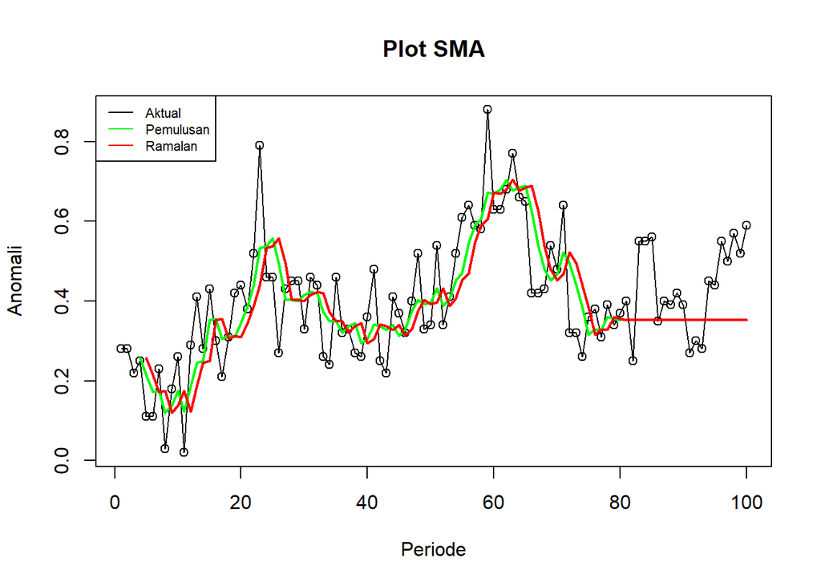

```r
ts.plot(data1.ts, xlab = "Periode", ylab = "Anomali",
        main = "Plot SMA")
points(data1.ts)
lines(data.gab.sma[,2], col = "green", lwd = 2)
lines(data.gab.sma[,3], col = "red", lwd = 2)
legend("topleft", c("Aktual", "Pemulusan", "Ramalan"),
       lty = 1, col = c("black", "green", "red"), cex = 0.7)
```

## Akurasi Data Latih - SMA

```r
error_train.sma <- train.ts - data.ramal.sma[1:length(train.ts)]
SSE_train.sma <- sum(error_train.sma[5:length(train.ts)]^2)
MSE_train.sma <- mean(error_train.sma[5:length(train.ts)]^2)
MAPE_train.sma <- mean(abs(error_train.sma[5:length(train.ts)]/train.ts[5:length(train.ts)])) * 100

akurasi_train.sma <- matrix(c(SSE_train.sma, MSE_train.sma, MAPE_train.sma))
row.names(akurasi_train.sma) <- c("SSE", "MSE", "MAPE")
colnames(akurasi_train.sma) <- "Akurasi Data Latih SMA"
akurasi_train.sma
```

```
##      Akurasi Data Latih SMA
## SSE              1.13813125
## MSE              0.01497541
## MAPE            43.28447381
```

## Akurasi Data Uji - SMA

```r
error_test.sma <- test.ts - data.gab.sma[(n_train+1):n, 3]
SSE_test.sma <- sum(error_test.sma^2)
MSE_test.sma <- mean(error_test.sma^2)
MAPE_test.sma <- mean(abs(error_test.sma/test.ts)) * 100

akurasi_test.sma <- matrix(c(SSE_test.sma, MSE_test.sma, MAPE_test.sma))
row.names(akurasi_test.sma) <- c("SSE", "MSE", "MAPE")
colnames(akurasi_test.sma) <- "Akurasi Data Uji SMA"
akurasi_test.sma
```

```
##      Akurasi Data Uji SMA
## SSE            0.36797500
## MSE            0.01839875
## MAPE          25.05862206
```

# Metode 2: Double Moving Average (DMA)

```r
dma <- SMA(data.sma, n = 4)
At <- 2 * data.sma - dma
Bt <- 2 / (4 - 1) * (data.sma - dma)
data.dma <- At + Bt
data.ramal2.dma <- c(NA, data.dma)

h <- length(test.ts)
f <- c()
for (i in 1:h) {
  f[i] <- At[length(At)] + Bt[length(Bt)] * i
}

data.gab2.dma <- cbind(
  aktual = c(data1.ts),
  pemulusan1 = c(data.sma, rep(NA, h)),
  pemulusan2 = c(dma, rep(NA, h)),
  At = c(At, rep(NA, h)),
  Bt = c(Bt, rep(NA, h)),
  ramalan = c(data.ramal2.dma, f[-1])
)
data.gab2.dma
```

```
##        aktual pemulusan1 pemulusan2       At            Bt    ramalan
##   [1,]   0.28         NA         NA       NA            NA         NA
##   [2,]   0.28         NA         NA       NA            NA         NA
##   [3,]   0.22         NA         NA       NA            NA         NA
##   [4,]   0.25     0.2575         NA       NA            NA         NA
##   [5,]   0.11     0.2150         NA       NA            NA         NA
##   [6,]   0.11     0.1725         NA       NA            NA         NA
##   [7,]   0.23     0.1750   0.205000 0.145000 -0.0200000000         NA
##   [8,]   0.03     0.1200   0.170625 0.069375 -0.0337500000 0.12500000
##   [9,]   0.18     0.1375   0.151250 0.123750 -0.0091666667 0.03562500
##  [10,]   0.26     0.1750   0.151875 0.198125  0.0154166667 0.11458333
##  [11,]   0.02     0.1225   0.138750 0.106250 -0.0108333333 0.21354167
##  [12,]   0.29     0.1875   0.155625 0.219375  0.0212500000 0.09541667
##  [13,]   0.41     0.2450   0.182500 0.307500  0.0416666667 0.24062500
##  [14,]   0.28     0.2500   0.201250 0.298750  0.0325000000 0.34916667
```

[output cut: 86 more lines]

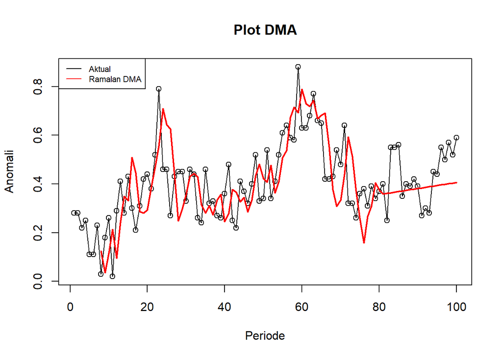

```r
ts.plot(data1.ts, xlab = "Periode", ylab = "Anomali",
        main = "Plot DMA")
points(data1.ts)
lines(data.gab2.dma[,6], col = "red", lwd = 2)
legend("topleft", c("Aktual", "Ramalan DMA"),
       lty = 1, col = c("black", "red"), cex = 0.7)
```

## Akurasi Data Latih - DMA

```r
error_train.dma <- train.ts - data.ramal2.dma[1:length(train.ts)]
SSE_train.dma <- sum(error_train.dma[8:length(train.ts)]^2)
MSE_train.dma <- mean(error_train.dma[8:length(train.ts)]^2)
MAPE_train.dma <- mean(abs(error_train.dma[8:length(train.ts)]/train.ts[8:length(train.ts)])) * 100

akurasi_train.dma <- matrix(c(SSE_train.dma, MSE_train.dma, MAPE_train.dma))
row.names(akurasi_train.dma) <- c("SSE", "MSE", "MAPE")
colnames(akurasi_train.dma) <- "Akurasi Data Latih DMA"
akurasi_train.dma
```

```
##      Akurasi Data Latih DMA
## SSE              1.45399796
## MSE              0.01991778
## MAPE            48.36652836
```

## Akurasi Data Uji - DMA

```r
error_test.dma <- test.ts - data.gab2.dma[(n_train+1):n, 6]
SSE_test.dma <- sum(error_test.dma^2)
MSE_test.dma <- mean(error_test.dma^2)
MAPE_test.dma <- mean(abs(error_test.dma/test.ts)) * 100

akurasi_test.dma <- matrix(c(SSE_test.dma, MSE_test.dma, MAPE_test.dma))
row.names(akurasi_test.dma) <- c("SSE", "MSE", "MAPE")
colnames(akurasi_test.dma) <- "Akurasi Data Uji DMA"
akurasi_test.dma
```

```
##      Akurasi Data Uji DMA
## SSE            0.26965625
## MSE            0.01348281
## MAPE          22.45285405
```

# Metode 3: Single Exponential Smoothing (SES)

SES cocok untuk data tanpa tren, namun tetap dicobakan sebagai pembanding. Digunakan nilai alpha optimum (dipilih otomatis oleh fungsi `ses()`).

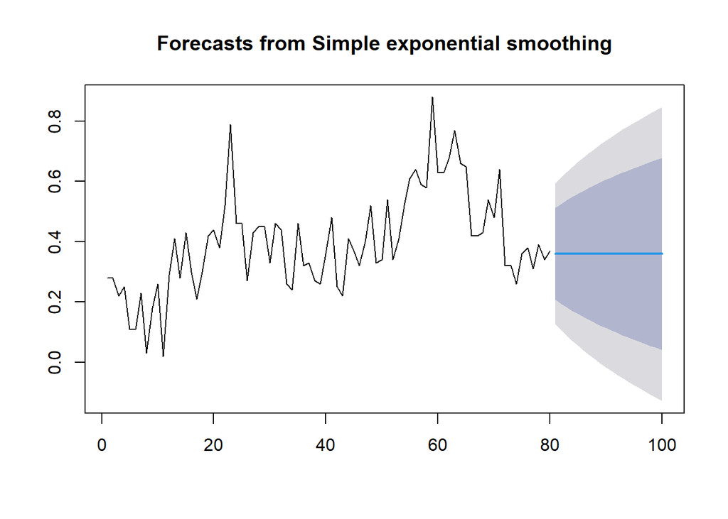

```r
ses.opt <- ses(train.ts, h = length(test.ts), alpha = NULL)
plot(ses.opt)
```

```r
ses.opt$model
```

```
## Simple exponential smoothing
##
## Call:
## ses(y = train.ts, h = length(test.ts), alpha = NULL)
##
##   Smoothing parameters:
##     alpha = 0.4217
##
##   Initial states:
##     l = 0.2525
##
##   sigma:  0.1189
##
##      AIC     AICc      BIC
## 13.87031 14.18610 21.01639
```

## Akurasi Data Latih - SES

```r
ses.fitted <- ses.opt$fitted
error_train.ses <- train.ts - ses.fitted
SSE_train.ses <- sum(error_train.ses^2)
MSE_train.ses <- mean(error_train.ses^2)
MAPE_train.ses <- mean(abs(error_train.ses/train.ts)) * 100

akurasi_train.ses <- matrix(c(SSE_train.ses, MSE_train.ses, MAPE_train.ses))
row.names(akurasi_train.ses) <- c("SSE", "MSE", "MAPE")
colnames(akurasi_train.ses) <- "Akurasi Data Latih SES"
akurasi_train.ses
```

```
##      Akurasi Data Latih SES
## SSE              1.10338081
## MSE              0.01379226
## MAPE            42.53334322
```

## Akurasi Data Uji - SES

```r
ses.forecast <- as.numeric(ses.opt$mean)
error_test.ses <- test.ts - ses.forecast
SSE_test.ses <- sum(error_test.ses^2)
MSE_test.ses <- mean(error_test.ses^2)
MAPE_test.ses <- mean(abs(error_test.ses/test.ts)) * 100

akurasi_test.ses <- matrix(c(SSE_test.ses, MSE_test.ses, MAPE_test.ses))
row.names(akurasi_test.ses) <- c("SSE", "MSE", "MAPE")
colnames(akurasi_test.ses) <- "Akurasi Data Uji SES"
akurasi_test.ses
```

```
##      Akurasi Data Uji SES
## SSE            0.34485039
## MSE            0.01724252
## MAPE          24.54988555
```

# Metode 4: Double Exponential Smoothing (DES)

Karena data memiliki pola tren, DES (Holt’s method dengan trend, tanpa musiman) diperkirakan lebih sesuai dibanding SES. Digunakan alpha dan beta optimum.

```r
des.opt <- HoltWinters(train.ts, gamma = FALSE)
des.opt
```

```
## Holt-Winters exponential smoothing with trend and without seasonal component.
##
## Call:
## HoltWinters(x = train.ts, gamma = FALSE)
##
## Smoothing parameters:
##  alpha: 0.42513
##  beta : 0
##  gamma: FALSE
##
## Coefficients:
##        [,1]
## a 0.3597153
## b 0.0000000
```

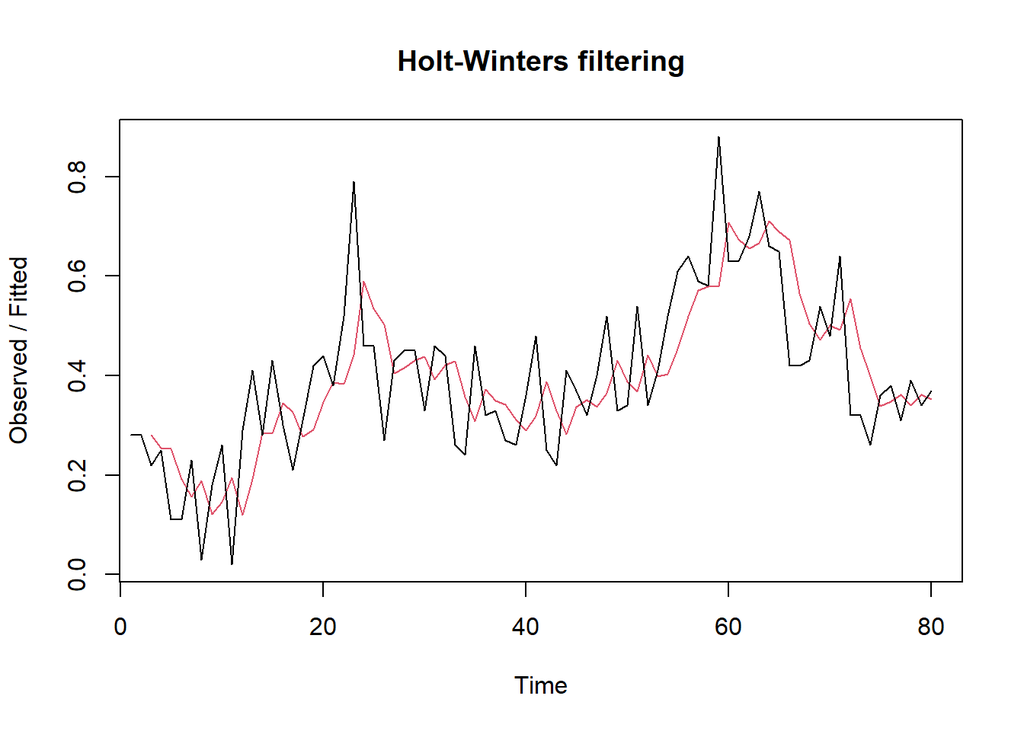

```r
plot(des.opt)
```

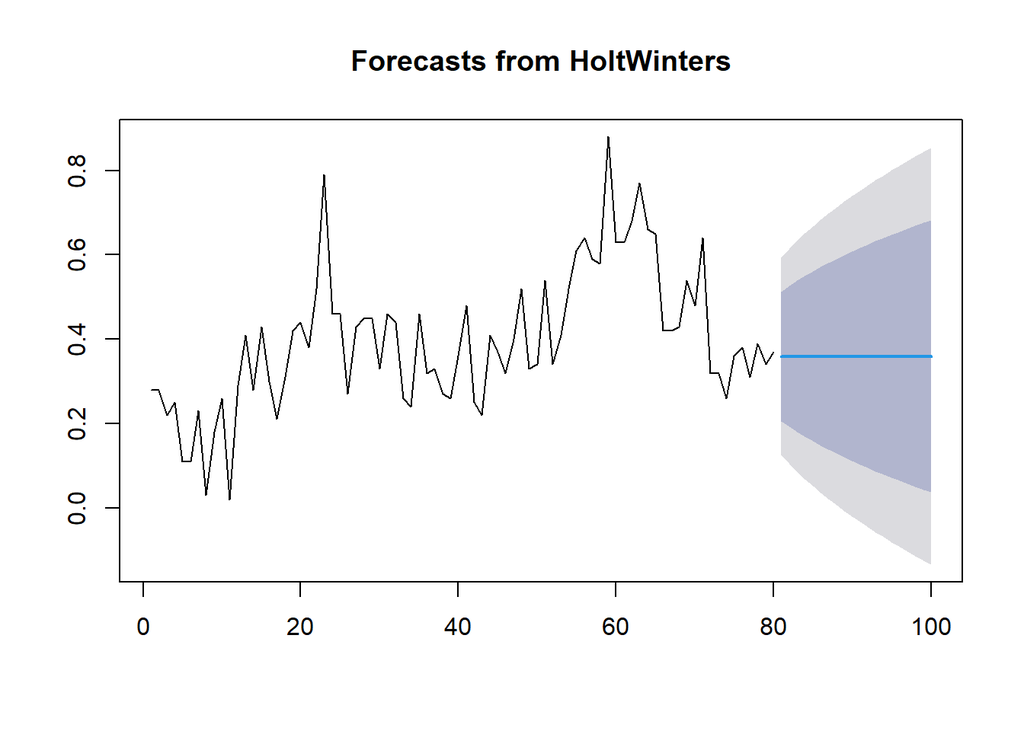

```r
ramalan.des <- forecast(des.opt, h = length(test.ts))
plot(ramalan.des)
```

## Akurasi Data Latih - DES

```r
des.fitted <- des.opt$fitted[,1]
error_train.des <- train.ts[-(1:2)] - des.fitted
SSE_train.des <- sum(error_train.des^2)
MSE_train.des <- mean(error_train.des^2)
MAPE_train.des <- mean(abs(error_train.des/train.ts[-(1:2)])) * 100

akurasi_train.des <- matrix(c(SSE_train.des, MSE_train.des, MAPE_train.des))
row.names(akurasi_train.des) <- c("SSE", "MSE", "MAPE")
colnames(akurasi_train.des) <- "Akurasi Data Latih DES"
akurasi_train.des
```

```
##      Akurasi Data Latih DES
## SSE              1.10450119
## MSE              0.01416027
## MAPE            43.61463458
```

## Akurasi Data Uji - DES

```r
des.forecast <- as.numeric(ramalan.des$mean)
error_test.des <- test.ts - des.forecast
SSE_test.des <- sum(error_test.des^2)
MSE_test.des <- mean(error_test.des^2)
MAPE_test.des <- mean(abs(error_test.des/test.ts)) * 100

akurasi_test.des <- matrix(c(SSE_test.des, MSE_test.des, MAPE_test.des))
row.names(akurasi_test.des) <- c("SSE", "MSE", "MAPE")
colnames(akurasi_test.des) <- "Akurasi Data Uji DES"
akurasi_test.des
```

```
##      Akurasi Data Uji DES
## SSE            0.34477268
## MSE            0.01723863
## MAPE          24.54809584
```

# Metode 5: Winter Aditif

Winter butuh data ts dengan frequency (periode musiman), jadi dibuat objek time series baru khusus (frequency = 12, karena data bulanan):

```r
train.ts.w <- ts(training$global_temperature_anomaly_C, frequency = 12, start = c(1993, 4))
test.ts.w  <- ts(testing$global_temperature_anomaly_C, frequency = 12)
h <- length(test.ts.w)
```

```r
winter1 <- HoltWinters(train.ts.w, seasonal = "additive")
winter1
```

```
## Holt-Winters exponential smoothing with trend and additive seasonal component.
##
## Call:
## HoltWinters(x = train.ts.w, seasonal = "additive")
##
## Smoothing parameters:
##  alpha: 0.3764229
##  beta : 0.03341179
##  gamma: 0.6538201
##
## Coefficients:
##              [,1]
## a    0.4146232654
## b    0.0005051317
## s1  -0.0142081443
## s2  -0.0657069540
## s3   0.0981246481
## s4  -0.1190103056
## s5  -0.1066125039
## s6  -0.1146953334
## s7   0.0077448432
## s8  -0.0261783370
## s9  -0.0478800395
## s10 -0.0703327788
## s11 -0.0799535174
## s12 -0.0393697351
```

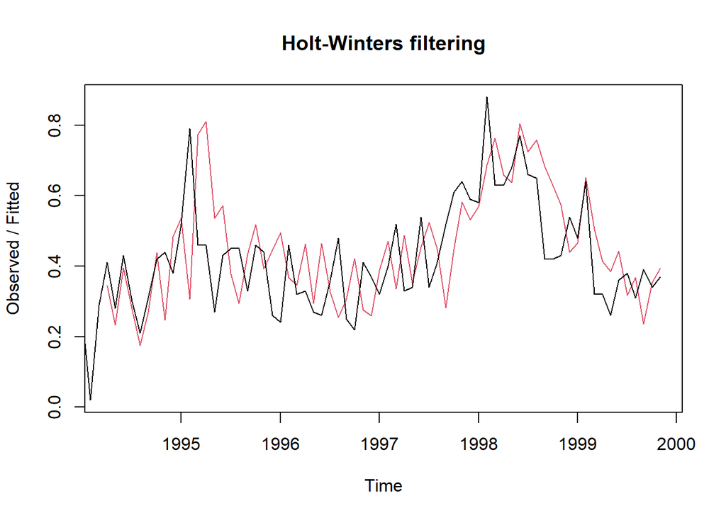

```r
plot(winter1)
```

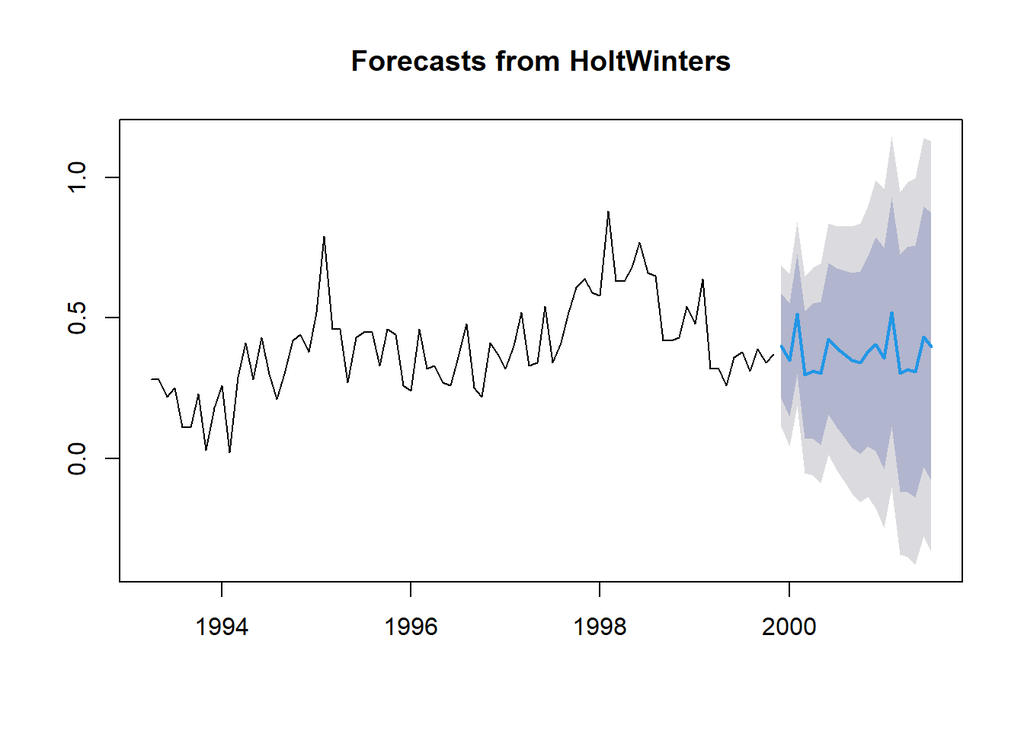

```r
ramalan.w1 <- forecast(winter1, h = h)
plot(ramalan.w1)
```

## Akurasi Data Latih - Winter Aditif

```r
fitted.w1 <- winter1$fitted[,1]
train.w1  <- window(train.ts.w, start = start(fitted.w1))
error_train.w1 <- as.numeric(train.w1) - as.numeric(fitted.w1)
SSE_train.w1 <- sum(error_train.w1^2)
MSE_train.w1 <- mean(error_train.w1^2)
MAPE_train.w1 <- mean(abs(error_train.w1/as.numeric(train.w1))) * 100

akurasi_train.w1 <- matrix(c(SSE_train.w1, MSE_train.w1, MAPE_train.w1))
row.names(akurasi_train.w1) <- c("SSE", "MSE", "MAPE")
colnames(akurasi_train.w1) <- "Akurasi Data Latih Winter Aditif"
akurasi_train.w1
```

```
##      Akurasi Data Latih Winter Aditif
## SSE                        1.46456034
## MSE                        0.02153765
## MAPE                      28.85151758
```

## Akurasi Data Uji - Winter Aditif

```r
forecast.w1 <- as.numeric(ramalan.w1$mean)
error_test.w1 <- as.numeric(test.ts.w) - forecast.w1
SSE_test.w1 <- sum(error_test.w1^2)
MSE_test.w1 <- mean(error_test.w1^2)
MAPE_test.w1 <- mean(abs(error_test.w1/as.numeric(test.ts.w))) * 100

akurasi_test.w1 <- matrix(c(SSE_test.w1, MSE_test.w1, MAPE_test.w1))
row.names(akurasi_test.w1) <- c("SSE", "MSE", "MAPE")
colnames(akurasi_test.w1) <- "Akurasi Data Uji Winter Aditif"
akurasi_test.w1
```

```
##      Akurasi Data Uji Winter Aditif
## SSE                      0.39387558
## MSE                      0.01969378
## MAPE                    24.69738790
```

# Metode 6: Winter Multiplikatif

```r
winter2 <- HoltWinters(train.ts.w, seasonal = "multiplicative")
winter2
```

```
## Holt-Winters exponential smoothing with trend and multiplicative seasonal component.
##
## Call:
## HoltWinters(x = train.ts.w, seasonal = "multiplicative")
##
## Smoothing parameters:
##  alpha: 0.001037989
##  beta : 0
##  gamma: 0.7761078
##
## Coefficients:
##          [,1]
## a   1.3932387
## b   0.0183377
## s1  0.4804786
## s2  0.4308363
## s3  0.5837696
## s4  0.3369142
## s5  0.3233043
## s6  0.2884319
## s7  0.3676759
## s8  0.3487799
## s9  0.3058567
## s10 0.3136443
## s11 0.2850709
## s12 0.3024670
```

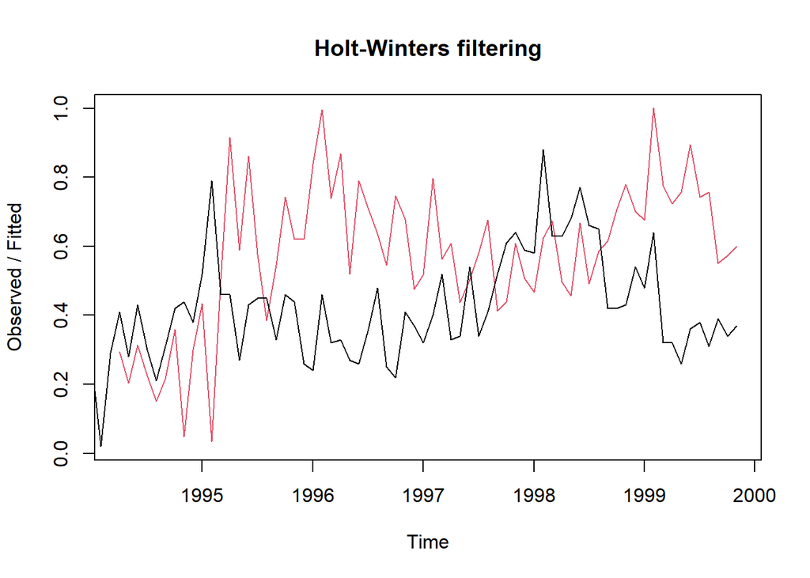

```r
plot(winter2)
```

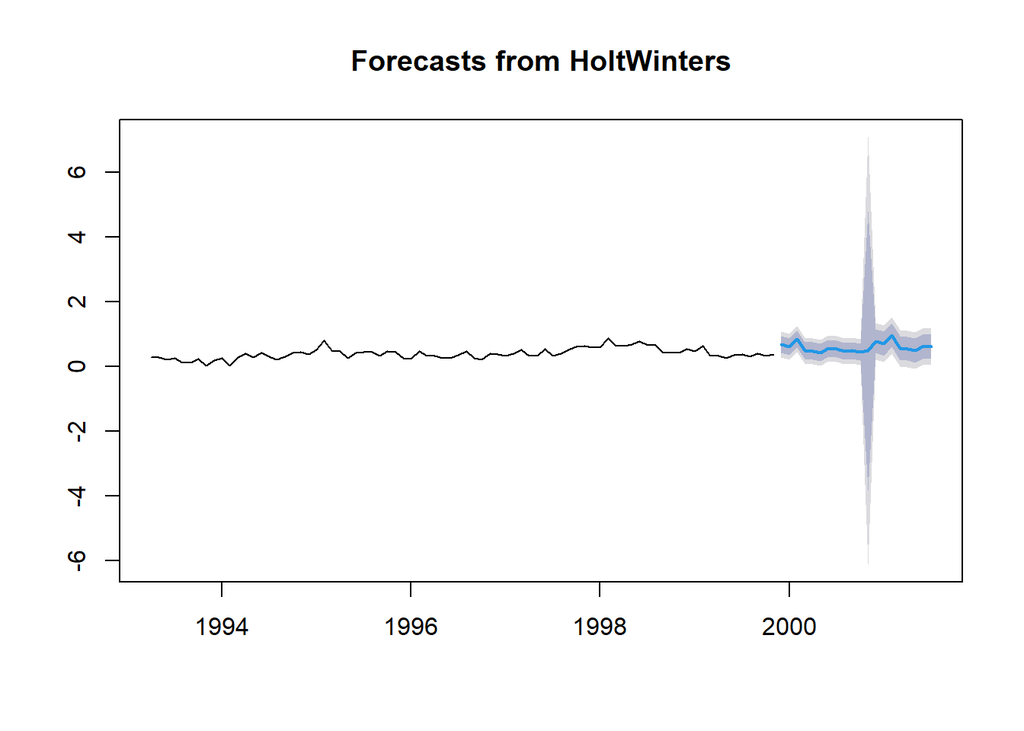

```r
ramalan.w2 <- forecast(winter2, h = h)
plot(ramalan.w2)
```

## Akurasi Data Latih - Winter Multiplikatif

```r
fitted.w2 <- winter2$fitted[,1]
train.w2  <- window(train.ts.w, start = start(fitted.w2))
error_train.w2 <- as.numeric(train.w2) - as.numeric(fitted.w2)
SSE_train.w2 <- sum(error_train.w2^2)
MSE_train.w2 <- mean(error_train.w2^2)
MAPE_train.w2 <- mean(abs(error_train.w2/as.numeric(train.w2))) * 100

akurasi_train.w2 <- matrix(c(SSE_train.w2, MSE_train.w2, MAPE_train.w2))
row.names(akurasi_train.w2) <- c("SSE", "MSE", "MAPE")
colnames(akurasi_train.w2) <- "Akurasi Data Latih Winter Multiplikatif"
akurasi_train.w2
```

```
##      Akurasi Data Latih Winter Multiplikatif
## SSE                               6.11037617
## MSE                               0.08985847
## MAPE                             67.82335235
```

## Akurasi Data Uji - Winter Multiplikatif

```r
forecast.w2 <- as.numeric(ramalan.w2$mean)
error_test.w2 <- as.numeric(test.ts.w) - forecast.w2
SSE_test.w2 <- sum(error_test.w2^2)
MSE_test.w2 <- mean(error_test.w2^2)
MAPE_test.w2 <- mean(abs(error_test.w2/as.numeric(test.ts.w))) * 100

akurasi_test.w2 <- matrix(c(SSE_test.w2, MSE_test.w2, MAPE_test.w2))
row.names(akurasi_test.w2) <- c("SSE", "MSE", "MAPE")
colnames(akurasi_test.w2) <- "Akurasi Data Uji Winter Multiplikatif"
akurasi_test.w2
```

```
##      Akurasi Data Uji Winter Multiplikatif
## SSE                             1.07624091
## MSE                             0.05381205
## MAPE                           48.98854952
```

# Perbandingan Metode & Kesimpulan

```r
perbandingan <- data.frame(
  Metode = c("SMA (m=4)", "DMA (m=4)", "SES (alpha optimum)",
             "DES (Holt, alpha & beta optimum)",
             "Winter Aditif", "Winter Multiplikatif"),
  SSE_Latih = c(SSE_train.sma, SSE_train.dma, SSE_train.ses, SSE_train.des,
                SSE_train.w1, SSE_train.w2),
  MSE_Latih = c(MSE_train.sma, MSE_train.dma, MSE_train.ses, MSE_train.des,
                MSE_train.w1, MSE_train.w2),
  MAPE_Latih = c(MAPE_train.sma, MAPE_train.dma, MAPE_train.ses, MAPE_train.des,
                 MAPE_train.w1, MAPE_train.w2),
  SSE_Uji = c(SSE_test.sma, SSE_test.dma, SSE_test.ses, SSE_test.des,
              SSE_test.w1, SSE_test.w2),
  MSE_Uji = c(MSE_test.sma, MSE_test.dma, MSE_test.ses, MSE_test.des,
              MSE_test.w1, MSE_test.w2),
  MAPE_Uji = c(MAPE_test.sma, MAPE_test.dma, MAPE_test.ses, MAPE_test.des,
               MAPE_test.w1, MAPE_test.w2)
)
knitr::kable(perbandingan, digits = 4)
```

| Metode | SSE_Latih | MSE_Latih | MAPE_Latih | SSE_Uji | MSE_Uji | MAPE_Uji |
| --- | --- | --- | --- | --- | --- | --- |
| SMA (m=4) | 1.1381 | 0.0150 | 43.2845 | 0.3680 | 0.0184 | 25.0586 |
| DMA (m=4) | 1.4540 | 0.0199 | 48.3665 | 0.2697 | 0.0135 | 22.4529 |
| SES (alpha optimum) | 1.1034 | 0.0138 | 42.5333 | 0.3449 | 0.0172 | 24.5499 |
| DES (Holt, alpha & beta optimum) | 1.1045 | 0.0142 | 43.6146 | 0.3448 | 0.0172 | 24.5481 |
| Winter Aditif | 1.4646 | 0.0215 | 28.8515 | 0.3939 | 0.0197 | 24.6974 |
| Winter Multiplikatif | 6.1104 | 0.0899 | 67.8234 | 1.0762 | 0.0538 | 48.9885 |

Keenam metode di atas dibandingkan untuk melihat metode mana yang paling sesuai dengan karakteristik data. Metode Winter (Aditif dan Multiplikatif) sengaja tetap disertakan sebagai pembanding/validasi terhadap dugaan awal bahwa data tidak memiliki pola musiman yang kuat.

**Metode terbaik dipilih berdasarkan nilai MAPE data uji terkecil** (karena MAPE tidak bergantung pada satuan/skala data sehingga lebih adil untuk dibandingkan antar metode).

```r
terbaik <- perbandingan$Metode[which.min(perbandingan$MAPE_Uji)]
terbaik
```

```
## [1] "DMA (m=4)"
```

Berdasarkan tabel perbandingan di atas, metode dengan **MAPE data uji terkecil** adalah metode yang dipilih sebagai metode pemulusan terbaik untuk data anomali suhu global ini, yaitu **DMA (m=4)** (lihat objek `terbaik`), dengan MAPE data uji sebesar 22.45%.

**Kesimpulan:** metode **DMA (m = 4)** dipilih sebagai metode pemulusan terbaik untuk data ini karena secara konsisten memberikan SSE, MSE, dan MAPE data uji yang paling kecil di antara SMA, SES, dan DES.

Ditambahkan pula perbandingan dengan metode musiman (Winter Aditif dan Winter Multiplikatif) sebagai validasi terhadap dugaan awal bahwa data tidak memiliki pola musiman. Hasilnya menunjukkan Winter Aditif memberikan MAPE data uji sebesar 24,70% (lebih baik dari SMA namun tetap kalah dari DMA), sedangkan Winter Multiplikatif memberikan hasil yang jauh lebih buruk (MAPE ≈ 49%) karena data tidak memiliki struktur musiman multiplikatif. Hal ini memperkuat kesimpulan bahwa DMA tetap menjadi metode pemulusan terbaik untuk data ini.